# Homework 11

Solutions will be available after Monday, November 9, 2026.

## Question 1: Implementing K-means

K-means is a relatively simple algorithm that we can write ourselves. For Questions 1 and 2, do not use an existing function that performs K-means directly.

Generate 10 observations with two independent standard normal coordinates. Set a random seed and report it. Randomly assign the observations to $K=2$ clusters, making sure neither cluster is empty. Let $C(i)$ denote the cluster assigned to observation $x_i$, and let $m_k$ denote the mean of cluster $k$.

1. Perform one iteration: calculate the cluster means, then assign each observation to its closest mean using Euclidean distance. Report the means and updated assignments, and plot the observations colored by their updated assignments.
2. Write a function that repeats these two steps until the assignments stop changing or a specified maximum number of iterations is reached. Your function should work for a data matrix with any number of variables and a chosen number of clusters $K$. Start from a nonempty assignment to each cluster; if a cluster becomes empty during iteration, keep its previous mean. Recalculate the cluster means from the final assignments before returning them. Return the final assignments, cluster means, and within-cluster sum of squares,

   $$\sum_{k=1}^K\sum_{i:\,C(i)=k}\lVert x_i-m_k\rVert^2.$$
3. Apply your function to the same 10 observations from two different random initial assignments. Report the final plots, cluster means, and within-cluster sums of squares. Do the two runs produce the same grouping and objective value? Explain your findings.

## Solution to Question 1

I use seed 43211. The data have two independent standard normal coordinates, and the same data are used for both random initializations.

```r
library(ggplot2)
set.seed(43211)

x <- matrix(rnorm(20), ncol = 2)
colnames(x) <- c("x1", "x2")
n <- nrow(x)
k <- 2

random_assignment <- function(n, k) {
  stopifnot(n >= k)
  assignment <- sample(rep(seq_len(k), length.out = n))
  stopifnot(all(tabulate(assignment, nbins = k) > 0))
  assignment
}

assignments <- random_assignment(n, k)
assignments
```

```
 [1] 2 1 1 1 1 2 2 2 2 1
```

The cluster means are calculated, and observations are assigned to their closest means.

```r
cluster_means <- function(x, assignments, previous_means = NULL) {
  k <- if (is.null(previous_means)) {
    max(assignments)
  } else {
    nrow(previous_means)
  }
  means <- matrix(NA_real_, nrow = k, ncol = ncol(x))

  for (cluster in seq_len(k)) {
    members <- assignments == cluster

    if (any(members)) {
      means[cluster, ] <- colMeans(x[members, , drop = FALSE])
    } else if (!is.null(previous_means)) {
      means[cluster, ] <- previous_means[cluster, ]
    }
  }

  colnames(means) <- colnames(x)
  means
}

closest_clusters <- function(x, means) {
  distances <- sapply(
    seq_len(nrow(means)),
    function(cluster) {
      rowSums((x - means[cluster, ])^2)
    }
  )
  max.col(-distances, ties.method = "first")
}

means <- cluster_means(x, assignments)
updated_assignments <- closest_clusters(x, means)

means
```

```
             x1         x2
[1,] 0.62211328  0.1828961
[2,] 0.03738818 -0.4525418
```

```r
updated_assignments
```

```
 [1] 1 1 2 1 2 1 2 2 2 2
```

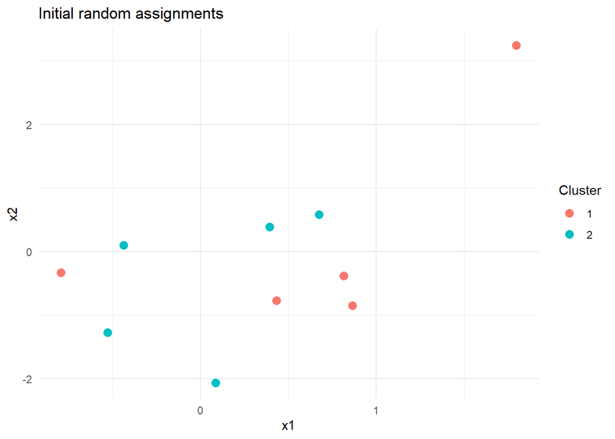

```r
one_iteration <- data.frame(
  x1 = x[, "x1"],
  x2 = x[, "x2"],
  cluster = factor(updated_assignments)
)

initial_plot <- data.frame(
  x1 = x[, "x1"],
  x2 = x[, "x2"],
  cluster = factor(assignments)
)

plot_assignments <- function(data, title) {
  ggplot(data, aes(x1, x2, color = cluster)) +
    geom_point(size = 3) +
    labs(title = title, color = "Cluster") +
    theme_minimal()
}

plot_assignments(initial_plot, "Initial random assignments")
```

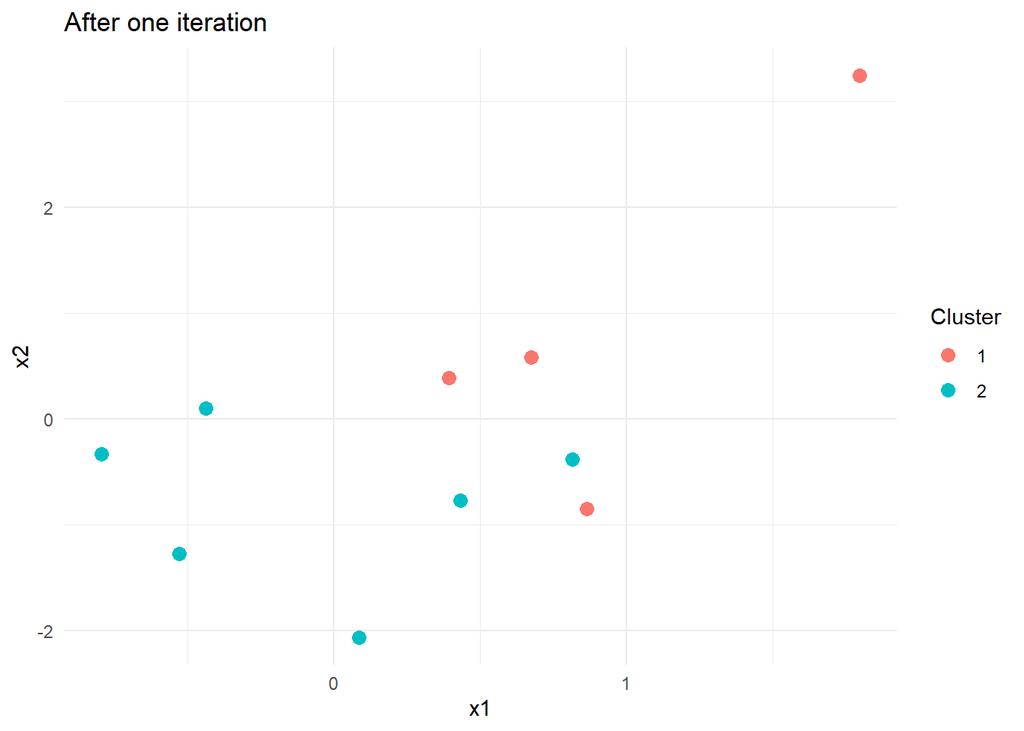

```r
plot_assignments(one_iteration, "After one iteration")
```

The function repeats these steps until convergence or the iteration limit. A previous mean is retained if a cluster becomes empty.

```r
kmeans_manual <- function(x, initial_assignments, max_iterations = 100) {
  stopifnot(is.matrix(x), is.numeric(x))
  stopifnot(length(initial_assignments) == nrow(x))

  assignments <- as.integer(initial_assignments)
  k <- max(assignments)
  stopifnot(setequal(sort(unique(assignments)), seq_len(k)))

  means <- cluster_means(x, assignments)

  for (iteration in seq_len(max_iterations)) {
    new_assignments <- closest_clusters(x, means)

    if (identical(new_assignments, assignments)) {
      break
    }

    assignments <- new_assignments
    means <- cluster_means(x, assignments, previous_means = means)
  }

  means <- cluster_means(x, assignments, previous_means = means)
  within_sum_squares <- sum(
    vapply(
      seq_len(k),
      function(cluster) {
        members <- assignments == cluster
        if (!any(members)) {
          return(0)
        }
        sum((x[members, , drop = FALSE] - means[cluster, ])^2)
      },
      numeric(1)
    )
  )

  list(
    assignments = assignments,
    means = means,
    within_sum_squares = within_sum_squares,
    iterations = iteration
  )
}

run_kmeans <- function(x, k, max_iterations = 100) {
  initial_assignments <- random_assignment(nrow(x), k)
  kmeans_manual(x, initial_assignments, max_iterations)
}

fit_one <- kmeans_manual(x, assignments)
fit_one$assignments
```

```
 [1] 2 2 2 1 2 2 2 2 2 2
```

```r
fit_one$means
```

```
            x1         x2
[1,] 1.7947730  3.2491712
[2,] 0.1669705 -0.5108222
```

```r
fit_one$within_sum_squares
```

```
[1] 14.29493
```

Two random initial assignments are used.

```r
initial_assignments <- replicate(
  2,
  random_assignment(n, k),
  simplify = FALSE
)

fits <- lapply(
  initial_assignments,
  function(start) kmeans_manual(x, start)
)

results <- data.frame(
  run = seq_along(fits),
  within_sum_squares = vapply(
    fits,
    function(fit) fit$within_sum_squares,
    numeric(1)
  ),
  iterations = vapply(
    fits,
    function(fit) fit$iterations,
    integer(1)
  )
)

results
```

```
  run within_sum_squares iterations
1   1           26.63292        100
2   2           14.29493          4
```

```r
lapply(fits, function(fit) fit$means)
```

```
[[1]]
            x1         x2
[1,] 0.4156916 -0.1521154
[2,] 0.1292220 -0.0944735

[[2]]
            x1         x2
[1,] 1.7947730  3.2491712
[2,] 0.1669705 -0.5108222
```

```r
lapply(fits, function(fit) fit$assignments)
```

```
[[1]]
 [1] 2 1 1 1 1 1 1 2 1 2

[[2]]
 [1] 2 2 2 1 2 2 2 2 2 2
```

Cluster labels may be switched without changing the grouping. Therefore, pairwise same-cluster indicators are compared.

```r
same_grouping <- function(first, second) {
  identical(outer(first, first, "=="), outer(second, second, "=="))
}

same_grouping(
  fits[[1]]$assignments,
  fits[[2]]$assignments
)
```

```
[1] FALSE
```

The final plots show the two resulting groupings.

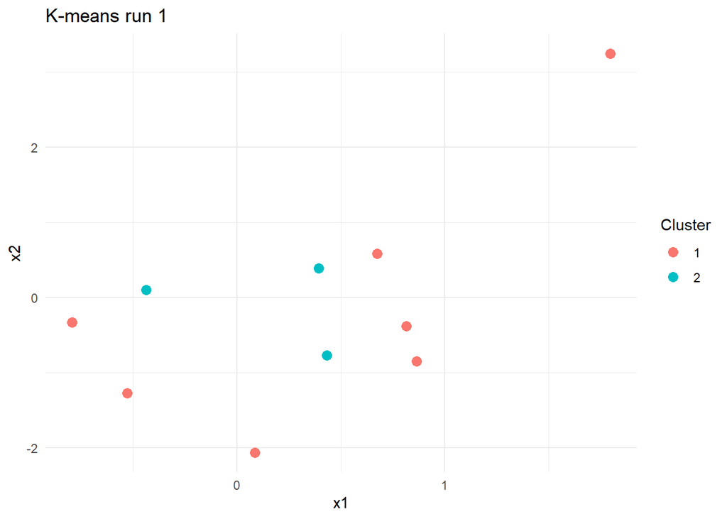

```r
plot_fit <- function(x, fit, run) {
  plot_data <- data.frame(
    x1 = x[, "x1"],
    x2 = x[, "x2"],
    cluster = factor(fit$assignments)
  )

  ggplot(plot_data, aes(x1, x2, color = cluster)) +
    geom_point(size = 3) +
    labs(
      title = paste("K-means run", run),
      color = "Cluster"
    ) +
    theme_minimal()
}

plot_fit(x, fits[[1]], 1)
```

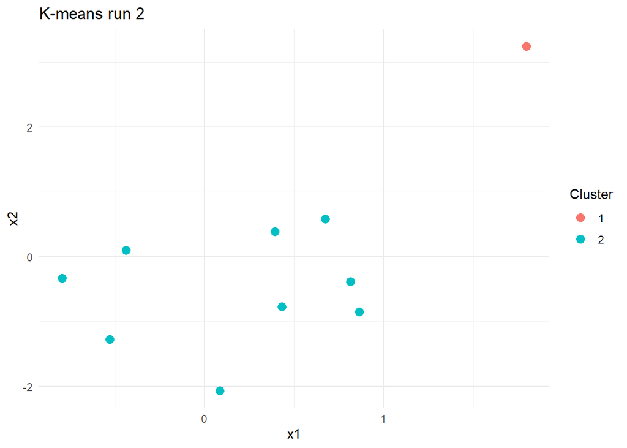

```r
plot_fit(x, fits[[2]], 2)
```

Different local solutions may be obtained because K-means depends on its initial assignments. The smaller within-cluster sum of squares is preferred.

## Question 2: Image color compression

Pick your favorite color image and use your K-means function from Question 1 to cluster its pixels. For computational efficiency, resize the image to no more than $200\times200$ pixels and use its three RGB color channels.

1. Plot the original image and report its dimensions. Transform it into a data matrix with one observation per pixel and three variables: red, green, and blue. Report the dimensions of this matrix.
2. For $K=2,3,5,10$, apply your function to the pixel data. Report the cluster means and within-cluster sum of squares for each $K$. Reconstruct and plot each compressed image by replacing every pixel with its assigned cluster mean. Use the same RGB scale for all fits.
3. Which value of $K$ would you choose for this image? Briefly justify your choice using the reconstructed images and the within-cluster sums of squares.

## Solution to Question 2

I use the image `Beckman-rotunda-entrance-fall-2018.jpg` and seed 43212. The original image is larger than the assignment limit, so I resize it by selecting equally spaced rows and columns. The RGB values are scaled between 0 and 1 by `readJPEG()`.

```r
library(jpeg)
library(ggplot2)

set.seed(43212)

image_name <- "Beckman-rotunda-entrance-fall-2018.jpg"
image <- readJPEG(image_name)
original_dimensions <- dim(image)
original_dimensions
```

```
[1] 3881 5930    3
```

```r
max_dimension <- 200
row_indices <- round(seq(
  1, nrow(image), length.out = min(nrow(image), max_dimension)
))
column_indices <- round(seq(
  1, ncol(image), length.out = min(ncol(image), max_dimension)
))

small_image <- image[row_indices, column_indices, , drop = FALSE]
small_dimensions <- dim(small_image)
small_dimensions
```

```
[1] 200 200   3
```

The original and resized images are displayed below.

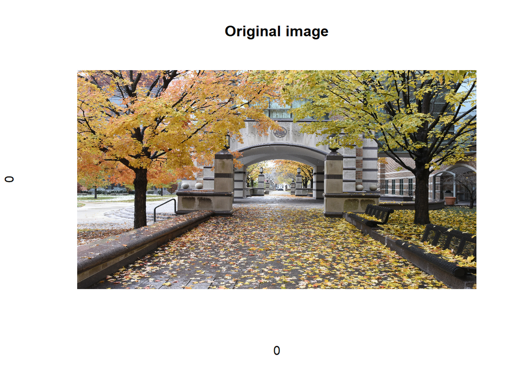

```r
plot_rgb_image <- function(image, title) {
  plot(
    0, 0,
    type = "n",
    xlim = c(0, ncol(image)),
    ylim = c(nrow(image), 0),
    xlab = NULL,
    ylab = NULL,
    axes = FALSE,
    main = title
  )
  rasterImage(
    image,
    0, nrow(image), ncol(image), 0,
    interpolate = FALSE
  )
}

plot_rgb_image(image, "Original image")
```

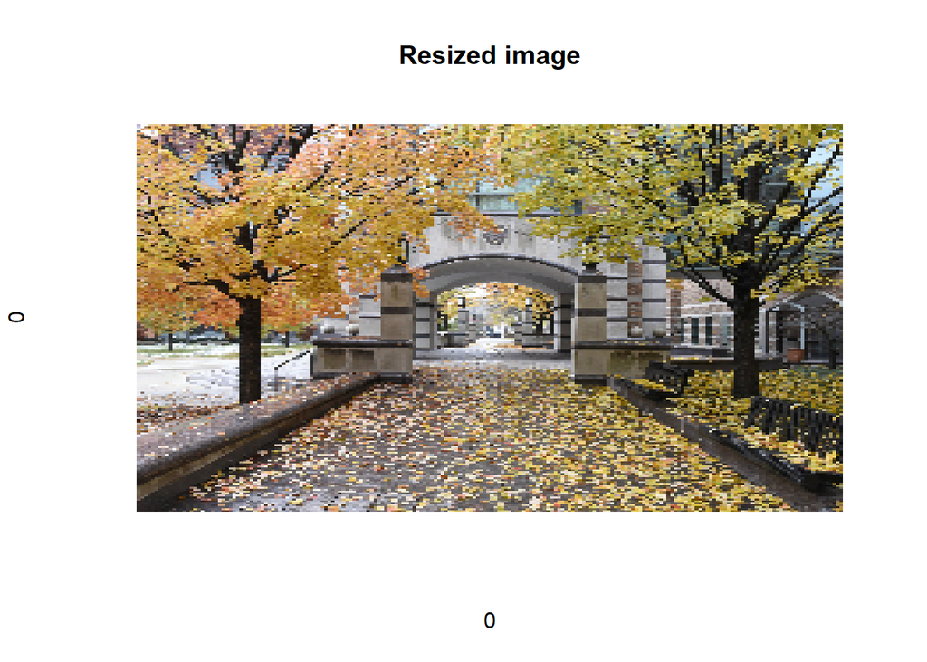

```r
plot_rgb_image(small_image, "Resized image")
```

Each pixel becomes one observation with three variables: red, green, and blue. The matrix is then clustered using the manual K-means function from Question 1.

```r
pixel_data <- matrix(
  c(small_image[, , 1], small_image[, , 2], small_image[, , 3]),
  ncol = 3
)
colnames(pixel_data) <- c("red", "green", "blue")
dim(pixel_data)
```

```
[1] 40000     3
```

```r
reconstruct_image <- function(pixel_data, fit, dimensions) {
  compressed_pixels <- fit$means[fit$assignments, , drop = FALSE]
  array(
    compressed_pixels,
    dim = c(dimensions[1], dimensions[2], 3)
  )
}

k_values <- c(2, 3, 5, 10)
fits <- lapply(
  k_values,
  function(k) run_kmeans(pixel_data, k)
)

compression_results <- data.frame(
  K = k_values,
  within_sum_squares = vapply(
    fits,
    function(fit) fit$within_sum_squares,
    numeric(1)
  )
)

compression_results
```

```
   K within_sum_squares
1  2           3848.520
2  3           2890.521
3  5           2913.728
4 10           2476.983
```

```r
lapply(fits, function(fit) fit$means)
```

```
[[1]]
           red     green      blue
[1,] 0.7395631 0.6729795 0.5384704
[2,] 0.3462164 0.2997044 0.2153233

[[2]]
           red     green      blue
[1,] 0.7980795 0.7419084 0.6295409
[2,] 0.5718571 0.4942713 0.3420860
[3,] 0.2415851 0.2115605 0.1601326

[[3]]
           red     green      blue
[1,] 0.2309868 0.2031123 0.1572001
[2,] 0.5912769 0.4613668 0.1680945
[3,] 0.5539184 0.4865808 0.3607895
[4,] 0.7690373 0.6457583 0.3746164
[5,] 0.8012158 0.7523039 0.6564362

[[4]]
            red     green      blue
 [1,] 0.4986627 0.4522336 0.3884705
 [2,] 0.1666654 0.1474333 0.1178750
 [3,] 0.7299826 0.6771221 0.5771150
 [4,] 0.7855815 0.6481440 0.3370115
 [5,] 0.8757423 0.7572362 0.5291877
 [6,] 0.6540968 0.5711268 0.4012189
 [7,] 0.8571784 0.8282491 0.7738784
 [8,] 0.6653394 0.5256511 0.2123144
 [9,] 0.5116925 0.3927171 0.1194028
[10,] 0.4072384 0.3544762 0.2592486
```

The following plots use the same RGB scale for all four compressed images.

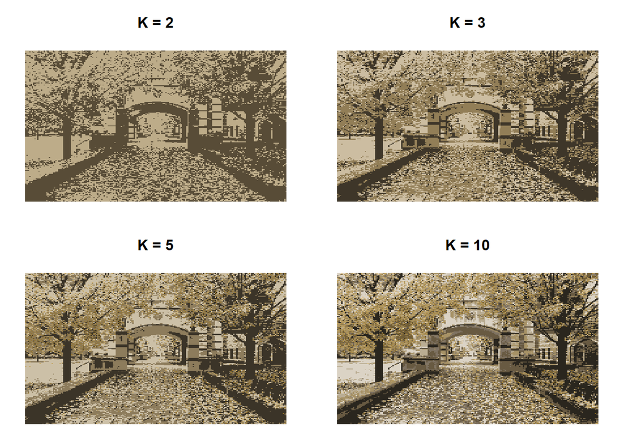

```r
par(mfrow = c(2, 2), mar = c(1, 1, 3, 1))

for (i in seq_along(k_values)) {
  compressed_image <- reconstruct_image(
    pixel_data,
    fits[[i]],
    dim(small_image)
  )
  plot_rgb_image(
    compressed_image,
    paste("K =", k_values[i])
  )
}
```

```r
par(mfrow = c(1, 1))
```

Among the available choices, $K=10$ is selected. It has the smallest within-cluster sum of squares and preserves more color detail than the smaller values. Even $K=10$ may not be enough for this image, but it is a reasonable choice among the values considered.

```r
chosen_k <- 10
compression_results[compression_results$K == chosen_k, ]
```

```
   K within_sum_squares
4 10           2476.983
```

## Question 3: Hierarchical clustering of cars

The file `data/mtcars.csv` contains 11 numerical variables for 32 cars, including fuel economy, horsepower, and weight. The `car` column gives the model names; use it to label observations, not as a clustering variable. You may use existing hierarchical clustering functions for this question.

1. Standardize each numerical variable to have mean 0 and standard deviation 1. Using Euclidean distance, perform hierarchical clustering with single, complete, and average linkage. Plot the three dendrograms with the car names and compare the results.
2. Choose one linkage method and a number of clusters that you consider reasonable. Report the cluster memberships and a table of cluster means on the original variable scales. Describe the main characteristics of the groups and explain your choice using the dendrogram and table. Briefly explain why standardizing the variables matters for this analysis.

## Solution to Question 3

Hierarchical clustering organizes the cars by repeatedly joining the closest groups. The linkage method defines the distance between groups: single linkage uses the closest pair, complete linkage uses the farthest pair, and average linkage uses the average pairwise distance.

```r
cars <- read.csv("data/mtcars.csv", check.names = FALSE)
car_names <- cars$car
car_data <- cars[, setdiff(names(cars), "car")]

stopifnot(nrow(cars) == 32, ncol(car_data) == 11)

standardized_data <- scale(car_data)
car_distances <- dist(standardized_data, method = "euclidean")

linkages <- c("single", "complete", "average")
hierarchical_fits <- lapply(
  linkages,
  function(linkage) hclust(car_distances, method = linkage)
)
names(hierarchical_fits) <- linkages
```

The three dendrograms are compared below. Standardization prevents variables with larger numerical scales, such as displacement and horsepower, from dominating the distances.

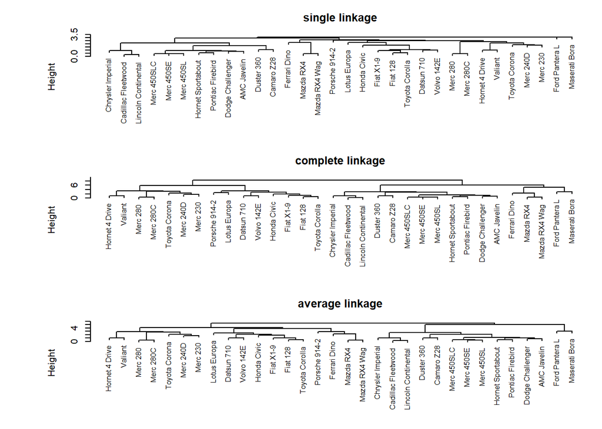

```r
par(mfrow = c(3, 1), mar = c(2, 8, 3, 1))

for (linkage in linkages) {
  plot(
    hierarchical_fits[[linkage]],
    labels = car_names,
    main = paste(linkage, "linkage"),
    xlab = NULL,
    sub = NULL,
    cex = 0.75
  )
}
```

```r
par(mfrow = c(1, 1))
```

Complete linkage with three clusters is selected. The memberships and cluster means are reported on the original variable scales.

```r
chosen_linkage <- "complete"
chosen_k <- 3
chosen_fit <- hierarchical_fits[[chosen_linkage]]
cluster_membership <- cutree(chosen_fit, k = chosen_k)

membership_table <- data.frame(
  car = car_names,
  cluster = cluster_membership
)
membership_table[order(membership_table$cluster), ]
```

```
                   car cluster
1            Mazda RX4       1
2        Mazda RX4 Wag       1
29      Ford Pantera L       1
30        Ferrari Dino       1
31       Maserati Bora       1
3           Datsun 710       2
4       Hornet 4 Drive       2
6              Valiant       2
8            Merc 240D       2
9             Merc 230       2
10            Merc 280       2
11           Merc 280C       2
18            Fiat 128       2
19         Honda Civic       2
```

[output cut: 18 more lines]

```r
cluster_means <- aggregate(
  car_data,
  by = list(cluster = cluster_membership),
  FUN = mean
)
cluster_means
```

```
  cluster      mpg      cyl     disp        hp     drat       wt    qsec
1       1 18.50000 6.800000 223.4000 198.80000 3.836000 3.001000 15.6160
2       2 24.65333 4.533333 131.6467  91.33333 3.897333 2.579867 19.1580
3       3 15.05000 8.000000 357.6167 194.16667 3.120833 4.104083 17.1425
         vs        am     gear     carb
1 0.0000000 1.0000000 4.600000 5.200000
2 0.9333333 0.5333333 3.933333 1.800000
3 0.0000000 0.0000000 3.000000 3.083333
```

The three-cluster solution is used because it gives a small number of interpretable groups while preserving the main separations in the complete-linkage dendrogram. The cluster means are interpreted on the original scales: lower `mpg` and higher `hp`, `disp`, and `wt` indicate larger, less fuel-efficient cars, while higher `mpg` and lower `wt` indicate smaller, more fuel-efficient cars.